# Section 7: Results Interpretation & Visualization

# 6. Results Interpretation & Visualization

## How to read part-worths/utilities

```r
# Create simulated part-worths for demonstration
set.seed(123)
partworths <- data.frame(
  attribute = c(
    rep("Brand", 4),
    rep("Price", 3),
    rep("Battery", 3),
    rep("Camera", 3)
  ),
  level = c(
    "Apple", "Samsung", "Google", "Xiaomi",
    "$400", "$700", "$1000",
    "15 hours", "20 hours", "25 hours",
    "16 MP", "64 MP", "128 MP"
  ),
  coefficient = c(
    runif(4, -0.5, 0.5),  # Brand
    c(0.8, 0.2, -0.6),    # Price (decreasing with higher price)
    c(-0.4, 0.1, 0.5),    # Battery (increasing with longer life)
    c(-0.3, 0.2, 0.4)     # Camera (increasing with higher MP)
  )
)
```

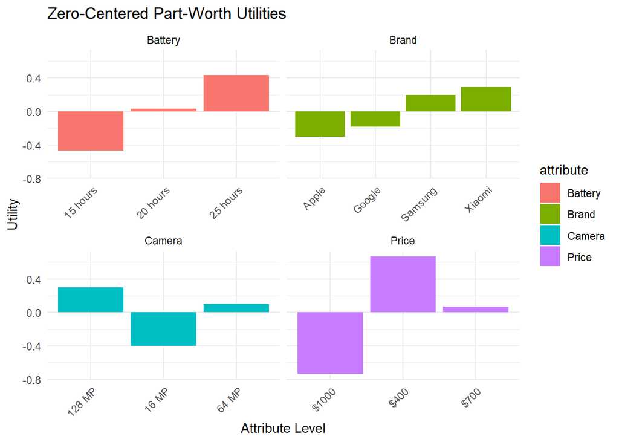

```r
# Calculate zero-centered part-worths
partworths <- partworths %>%
  group_by(attribute) %>%
  mutate(
    zero_centered = coefficient - mean(coefficient)
  ) %>%
  ungroup()

# Calculate attribute importance
importance <- partworths %>%
  group_by(attribute) %>%
  summarize(
    importance = max(zero_centered) - min(zero_centered),
    .groups = "drop"
  ) %>%
  mutate(
    relative_importance = importance / sum(importance) * 100
  )

# Display part-worths
ggplot(partworths, aes(x = level, y = zero_centered, fill = attribute)) +
  geom_bar(stat = "identity") +
  facet_wrap(~ attribute, scales = "free_x") +
  labs(title = "Zero-Centered Part-Worth Utilities",
       x = "Attribute Level", y = "Utility") +
  theme_minimal() +
  theme(axis.text.x = element_text(angle = 45, hjust = 1))
```

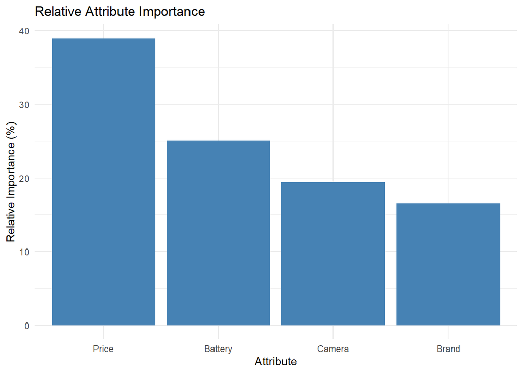

```r
# Display attribute importance
ggplot(importance, aes(x = reorder(attribute, -relative_importance), y = relative_importance)) +
  geom_bar(stat = "identity", fill = "steelblue") +
  labs(title = "Relative Attribute Importance",
       x = "Attribute", y = "Relative Importance (%)") +
  theme_minimal()
```

**How to Interpret Part-Worth Utilities**

The first chart shows zero-centered part-worth utilities for each attribute level. Within each attribute: - Higher values indicate stronger preference - The range of values shows how much that attribute influences choices - The difference between levels shows the relative preference between options

The second chart shows the relative importance of each attribute, calculated as the range of part-worths within each attribute divided by the sum of ranges across all attributes. This indicates how much each attribute drives consumer choices.

## How to read MaxDiff scores

```r
# Create simulated MaxDiff scores for demonstration
set.seed(456)
maxdiff_coefs <- data.frame(
  item = c(
    "Long battery life",
    "Fast charging",
    "High-resolution display",
    "Water resistance",
    "Compact design",
    "Expandable storage",
    "Wireless charging",
    "Advanced camera features",
    "Biometric security",
    "5G connectivity"
  ),
  coefficient = c(1.2, 0.8, 0.3, -0.2, -0.5, -0.8, 0.2, 0.9, -0.1, 0.4)
)
```

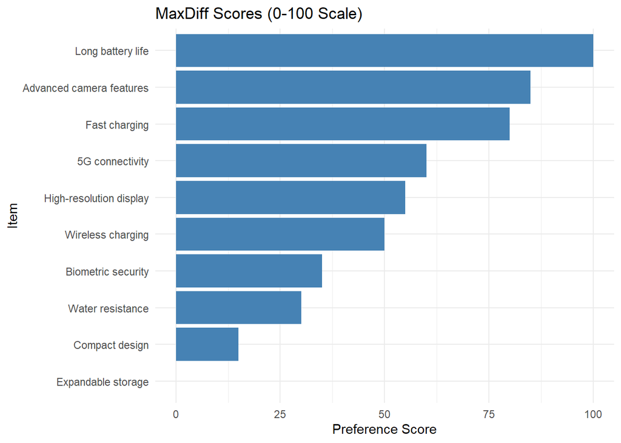

```r
# Rescale logit coefficients to 0-100 scale
maxdiff_coefs <- maxdiff_coefs %>%
  mutate(
    rescaled_score = (coefficient - min(coefficient)) /
                     (max(coefficient) - min(coefficient)) * 100
  )

# Display rescaled scores
ggplot(maxdiff_coefs, aes(x = reorder(item, rescaled_score), y = rescaled_score)) +
  geom_bar(stat = "identity", fill = "steelblue") +
  coord_flip() +
  labs(title = "MaxDiff Scores (0-100 Scale)",
       x = "Item", y = "Preference Score") +
  theme_minimal()
```

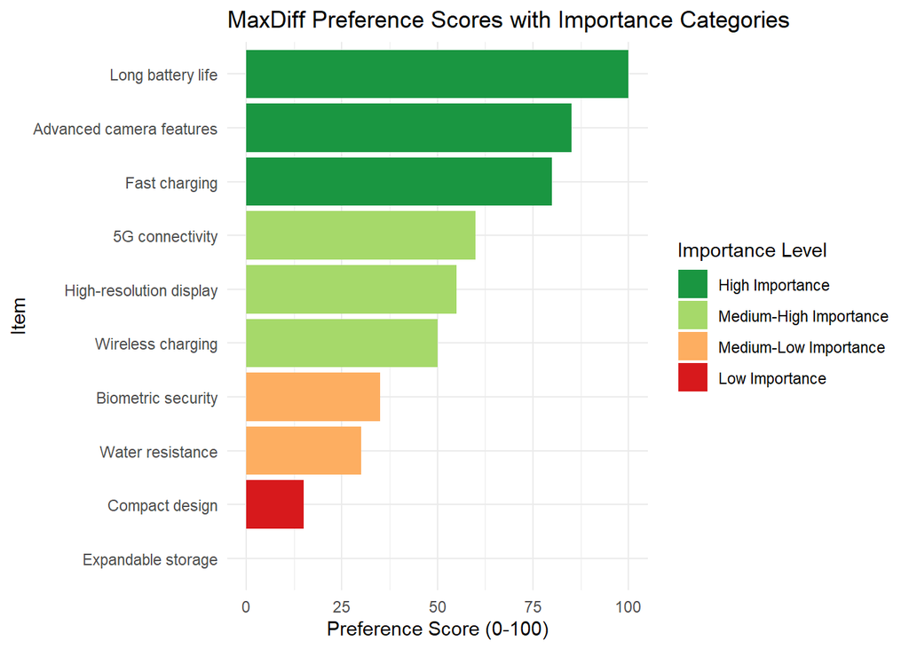

```r
# Create a more informative visualization
maxdiff_viz <- maxdiff_coefs %>%
  mutate(
    category = case_when(
      rescaled_score >= 75 ~ "High Importance",
      rescaled_score >= 50 ~ "Medium-High Importance",
      rescaled_score >= 25 ~ "Medium-Low Importance",
      TRUE ~ "Low Importance"
    ),
    category = factor(category, levels = c(
      "High Importance", "Medium-High Importance",
      "Medium-Low Importance", "Low Importance"
    ))
  )

ggplot(maxdiff_viz, aes(x = reorder(item, rescaled_score), y = rescaled_score, fill = category)) +
  geom_bar(stat = "identity") +
  coord_flip() +
  scale_fill_manual(values = c(
    "High Importance" = "#1a9641",
    "Medium-High Importance" = "#a6d96a",
    "Medium-Low Importance" = "#fdae61",
    "Low Importance" = "#d7191c"
  )) +
  labs(title = "MaxDiff Preference Scores with Importance Categories",
       x = "Item", y = "Preference Score (0-100)",
       fill = "Importance Level") +
  theme_minimal()
```

**How to Interpret MaxDiff Scores**

The charts above show MaxDiff preference scores rescaled to a 0-100 scale: - Higher scores indicate stronger preference or importance - The scores are interval-scaled, meaning the differences between scores are meaningful - Items can be categorized into importance tiers (as shown in the second chart) - The relative spacing between items shows how much more important one item is than another

These scores can be used to prioritize features, benefits, or messaging in product development and marketing.

## Compare across segments

```r
# Create simulated segment data for demonstration
set.seed(789)

# For MaxDiff
maxdiff_segments <- data.frame(
  item = rep(maxdiff_coefs$item, 3),
  segment = rep(c("Tech Enthusiasts", "Budget Conscious", "Camera Lovers"), each = 10),
  rescaled_score = c(
    # Tech Enthusiasts prioritize advanced features
    c(80, 60, 70, 30, 20, 40, 65, 75, 55, 90),
    # Budget Conscious prioritize value
    c(60, 70, 40, 20, 50, 90, 30, 40, 45, 35),
    # Camera Lovers prioritize camera and display
    c(50, 40, 90, 30, 20, 25, 35, 95, 40, 60)
  )
)

# For Conjoint
conjoint_segments <- data.frame(
  brand = rep(c("Apple", "Samsung", "Google", "Xiaomi"), 3),
  segment = rep(c("Tech Enthusiasts", "Budget Conscious", "Camera Lovers"), each = 4),
  percentage = c(
    # Tech Enthusiasts prefer Apple and Google
    c(40, 25, 25, 10),
    # Budget Conscious prefer Xiaomi and Samsung
    c(15, 35, 10, 40),
    # Camera Lovers prefer Samsung and Apple
    c(35, 45, 10, 10)
  )
)
```

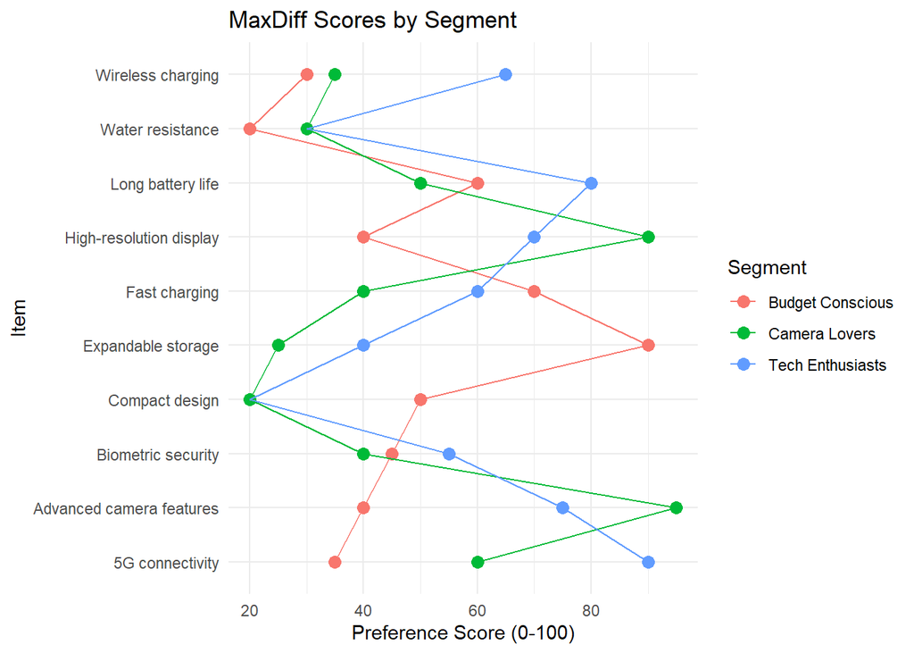

```r
# Visualize segment comparison for MaxDiff
ggplot(maxdiff_segments, aes(x = item, y = rescaled_score, color = segment, group = segment)) +
  geom_point(size = 3) +
  geom_line() +
  coord_flip() +
  labs(title = "MaxDiff Scores by Segment",
       x = "Item", y = "Preference Score (0-100)", color = "Segment") +
  theme_minimal()
```

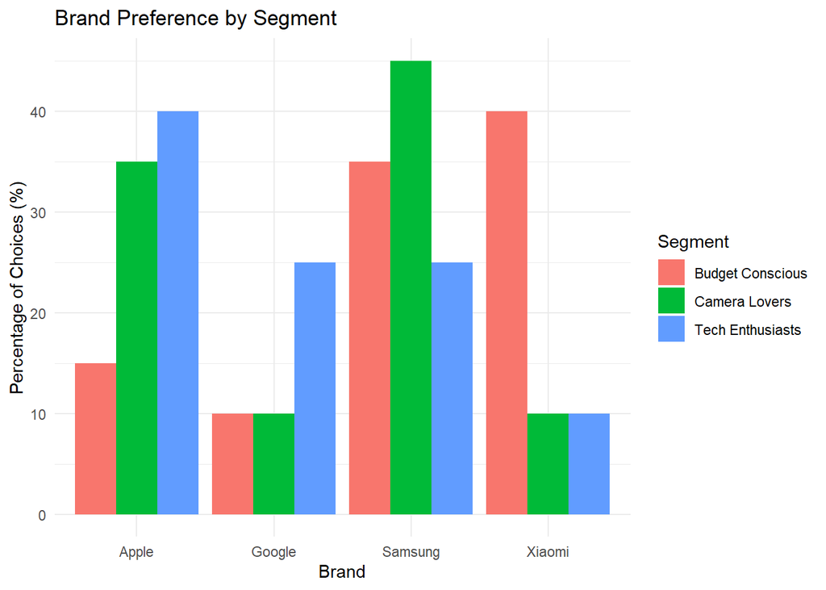

```r
# Visualize segment comparison for brand preference
ggplot(conjoint_segments, aes(x = brand, y = percentage, fill = segment)) +
  geom_bar(stat = "identity", position = "dodge") +
  labs(title = "Brand Preference by Segment",
       x = "Brand", y = "Percentage of Choices (%)", fill = "Segment") +
  theme_minimal()
```

**Segment Comparison**

The charts above show how preferences differ across customer segments:

For MaxDiff analysis: - Different segments prioritize different features - The lines show the preference patterns for each segment - Crossing lines indicate areas of disagreement between segments

For Conjoint analysis: - Brand preferences vary significantly by segment - Some segments show stronger preference for certain brands - These differences can inform targeted marketing strategies

Segment-specific insights allow for more targeted product development and marketing strategies.